# The New York City Housing Crisis: Quality and Quantity

Aliana Calpe, Arnav Raja, Jaden Clarke, Jiawei Gao, Sophie Chinn

2024-12-10

## Introduction

Post-pandemic, many major US cities have been suffering from housing crises, namely, New York City. Rising costs and housing scarcity have contributed to a decrease in quality of life for New Yorkers, as well as increasing risks of housing insecurity. In February 2024, only 1.4% of rentals were available (Zaveri 2024), where typically 5-8% is an ideal vacancy rate (anything under 5% qualifying as a housing crisis). The vacancy rate was already under 5% before the pandemic and remained so during the pandemic - the rebound post-pandemic created a stress on housing demand that could not be met by the city. This has also driven up rent as well as aggravating the already present homelessness crisis. Because of this lack of resources, families and working class New Yorkers are being forced out of the city. Additionally, the burden of this crisis disproportionately affects people of color, with Hispanic, Black, and Asian New Yorkers being at least 1.5% more likely to be facing housing insecurity (Office of Budget Policy and Analysis 2024).

Once again, the brunt of this burden falls on people of color. The New York City Mayor’s Office of Climate Change and Environmental Justice found that historically redlined neighborhoods of New York City, which are predominantly inhabited by people of color, report the highest number of maintenance deficiencies in their housing (2024). Notably, nine out of the top ten neighborhoods that had three or more housing maintenance deficiencies were located in the Bronx. The failing quality of housing has major implications for its residents, particularly related to health. Poor housing quality has been shown to increase the likelihood of asthma, which is most prevalent in the Bronx, constituting 33% of asthma cases in the city (CHCP).

New York City publishes robust datasets detailing information about the vacant and occupied units in the city as well as the people who occupy them and the conditions of the units. We can take advantage of these datasets in order to examine the question of housing quality and factors driving it. In doing this, it is imperative to consider the disparities of housing quality for people of color in this dataset, given that research extensively shows the inequality that exists in housing for people of color in New York City.

The housing crisis in New York City is an urgent humanitarian issue. By exploring some of these variables in the dataset, we can gain a deeper understanding of what particular factors are driving housing quality issues in New York City and, in turn, find solutions to make New York City a more livable place for its residents.

## Our Question

How does housing availability and quality vary across different neighborhoods in New York City, and what factors contribute to these disparities?

## Packages

```r
library(tidyverse)
library(tidymodels)
library(ggplot2)
library(tidytext)
```

## The Data

The dataset that we are using came from the New York City Housing and Vacancy Survey (NYCHVS), which is a citywide, representative survey of New York City’s housing and population. This dataset came from the 2021 survey done by the US Census Bureau. About 12,000 units throughout the city were surveyed using the 2020 July Master Address File (MAF) which makes sure that the data are representative of the entire residential units in the five boroughs of New York City, with each unit representing about 435 similar housing units.

There are four datasets that the NYCHVS has released to the public and has all the data they have acquired. The all units dataset, occupied units dataset, person dataset, and vacant units dataset.

The all units dataset contains data and information about the unit and building itself, like the size of the unit, the borough in which the unit is located, and the housing type. This dataset can be used to obtain the characteristics of the units and the overall amount of units surveyed.

The occupied dataset has data about units that were occupied at the time the 2021 survey was conducted. It has information on the household, the unit, and the buildings that were occupied like how many people are in the household, how much rent they have to pay, how much utilities are, and more.

The person dataset is data more on the individual answering the survey than the unit itself. It contains information on them like their age, gender, race/ethnicity, and work details. For this dataset, there is a record for each person in the unit.

The vacant dataset has more on the units that were not occupied at the time of the survey, including units that were available for rent or for sale and those that were not. This dataset has data on vacancy length, asking price or rent of the unit, and what the last rent was before it became vacant.

All these datasets have one column in common, which is control. Through this column, we are able to combine the four datasets into one. Control is the numeric identifier for each housing unit.

The user guide and codebook for the datasets can be found at:

https://www2.census.gov/programs-surveys/nychvs/technical-documentation/record-layouts/2021/2021_NYCHVS_PUF_User_Guide_and_Codebook.pdf

## Data Import / Wrangling

To start off, we imported our four datasets and assigned them variable names.

```r
#the following filepaths are for jaden's computer. To use the paths on datahub comment these out and uncomment the ones below (highlight and hit ctl + shift + c)
filepaths <- c(
r"{C:\Users\SmotP\Downloads\occupied_puf_21.csv}",
r"{C:\Users\SmotP\Downloads\allunits_puf_21.csv}",
r"{C:\Users\SmotP\Downloads\vacant_puf_21.csv}",
r"{C:\Users\SmotP\Downloads\person_puf_21.csv}"
)
 filepaths <- c(
 r"{occupied_puf_21.csv}",
 r"{allunits_puf_21.csv}",
 r"{vacant_puf_21.csv}",
 r"{person_puf_21.csv}"
 )
occupied_data <- read.csv(filepaths[1])
all_units_data <- read.csv(filepaths[2])
vacant_data <- read.csv(filepaths[3])
person_data <- read.csv(filepaths[4])
```

Here, we recoded the labels for some of the columns across all four datasets to improve clarity and more efficient interpretation. Since the original column labels were integers, understanding their meaning required referencing the guidebook. So to make the data more intuitive and allow for detailed data analysis, we recoded the columns that we felt needed more descriptive labels. This step makes the data easier to work with during analysis, reduces potential for errors, and be more understandable in communicating what our results are. Some columns we decided need recoding are the boro column from the all units dataset to make the labels the names of the actual boroughs instead of the number that represents them, the type of tenure in the occupied dataset, and more. In this, as we have over 400 columns for the datasets combined, we also combined columns that have similar information like combining all the ocunts of diabilities in a household or how much debt the household acquired to make the datasets easier to work with and lessen the amount of columns needed for analysis.

The code for recoding the survey data was provided by ChatGPT and was added to / edited by members of the team

We used janitor to get the column names into a more usable format and to ensure that each column follows the same format for clarity and easier readability.

```r
occupied_data <- occupied_data |> janitor::clean_names()
all_units_data <- all_units_data |> janitor::clean_names()
vacant_data <- vacant_data |> janitor::clean_names()
person_data <- person_data |> janitor::clean_names()
```

This code applies the data-wrangling functions to clean and preprocess the four datasets. Each function performs transformations tailored to each dataset that was written in the above codes. These transformations includes recoding values, reorganizing columns for clarity, and converting numeric values into more meaningful categorical labels. By using the wrangling functions, we make sure that the datasets are in a ready to be analyzed with detailed descriptions.

```r
all_units_data <- refactor_allunits(all_units_data)
vacant_data <- refactor_vacant(vacant_data)
occupied_data <- refactor_occupied(occupied_data)
person_data <- refactor_person_data(person_data)
```

After we recoded and wrangles each dataset, we combined all four into a single dataset to be used for analysis.

```r
combined_data <- merge(occupied_data, all_units_data, by = "control", all = TRUE)

combined_data <- merge(combined_data, vacant_data, by = "control", all = TRUE)

combined_data <- merge(combined_data, person_data, by = "control", all = TRUE)
```

At this point, the dataset is ready but while wrangling, we realized that some columns are not necessary for answering our question of how housing availability and quality vary across different neighborhoods and what factors contribute to these, so we dropped those columns by selecting what specific columns we wanted to analyze further.

```r
combined_data <- combined_data|>
  select(control, tenure, hhfirstmovein, control, gender_p, maritalstat_p, spouse_p, spouse_res_p, raceeth_p, edattain_p, movein_p, race_p, disability, boro, occ, csr, condocoop, stories, elevator, units, unit_floor, unit_oneplusflight, elev_no_steps, unit_no_steps, yearbuilt, bedrooms, rooms, fullbath_num, halfbath_num, firstocc, reason_notavail, own, lastrent_clean, vac_length, askingrent, askingprice, i_askingrent, i_askingprice, rent_expenditure, rent_amount, disability, receives_assistance, total_rent_cost, total_debt, tenure, foodinsecure, rentburden_cat, total_debt, disability, gender_p, maritalstat_p, spouse_p, spouse_res_p,raceeth_p, edattain_p, musty_freq, elevator_status, rodents_unit, rodents_building, toilet_status, roaches_count, wall_holes, floor_holes, peeling_paint, large_peeling_paint, maintenance_deficiency_count, hhpoverty, hhsize, crowding)
```

## EDA

```r
print(unique(combined_data$rentburden_cat))
```

```
## [1] "Means-tested housing" "Severely burdened"    "Moderately burdened"
## [4] "Not burdened"         "Not applicable"       NA
```

```r
print(unique(combined_data$hhpoverty))
```

[output not shown]

```r
# range of poverty is 0 (0.5%) to 250 (250% and more).
```

```r
# Summary statistics of household size, rent burden, poverty status, and utility interruptions
Poverty_threshold <- 100 # median value from range of poverty

combined_stats <- combined_data |>
  filter(hhpoverty != "Not applicable",) |>
  group_by(boro) |>
  summarize(
    avg_household_size = mean(hhsize, na.rm = TRUE),
    avg_rent_burden = mean(rent_expenditure, na.rm = TRUE),
    percent_poverty = mean(hhpoverty <= Poverty_threshold, na.rm = TRUE) * 100,
  )

print(combined_stats)
```

```
## # A tibble: 5 × 4
##   boro          avg_household_size avg_rent_burden percent_poverty
##   <fct>                      <dbl>           <dbl>           <dbl>
## 1 Bronx                       2.95             Inf            32.8
## 2 Brooklyn                    3.21             Inf            15.2
## 3 Manhattan                   2.65             Inf            16.7
## 4 Queens                      3.41             Inf            14.6
## 5 Staten Island               3.61             Inf            18.6
```

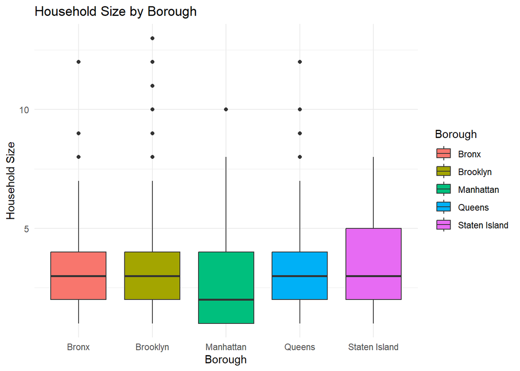

```r
# Visualize household size across boroughs
ggplot(combined_data, aes(x = boro, y = hhsize, fill = boro)) +
  geom_boxplot() +
  labs(title = "Household Size by Borough", x = "Borough", y = "Household Size", fill = 'Borough') +
  theme_minimal()
```

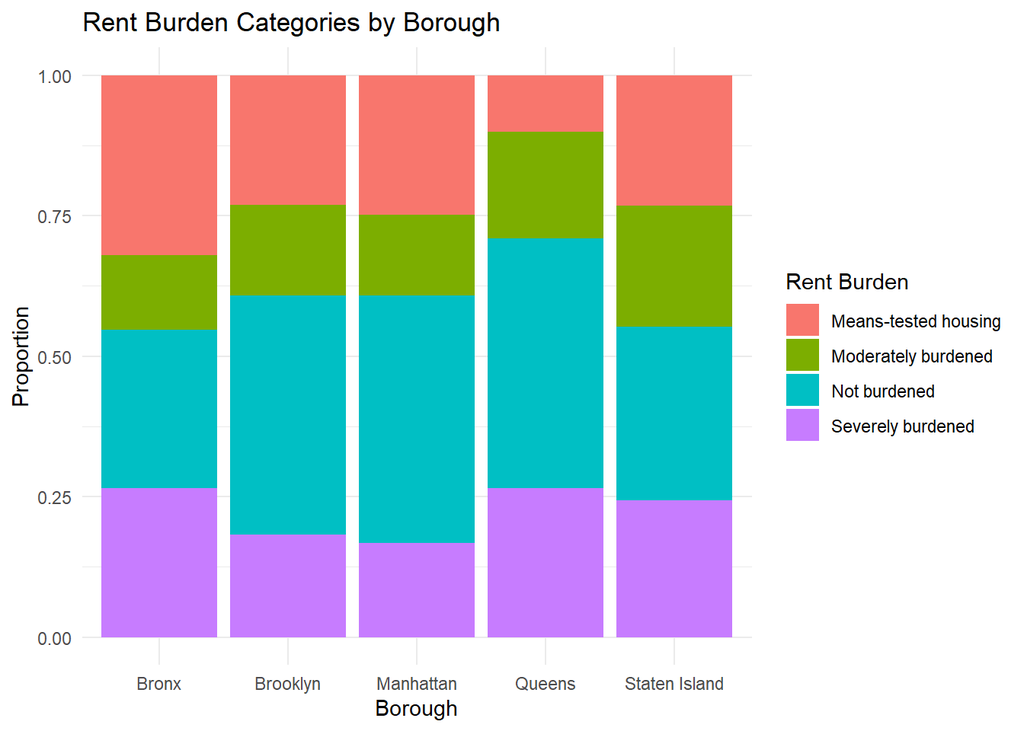

```r
ggplot(combined_data |> filter( rentburden_cat != "Not applicable"), aes(x = boro, fill = rentburden_cat)) +
  geom_bar(position = "fill") +
  labs(
    title = "Rent Burden Categories by Borough",
    x = "Borough",
    y = "Proportion",
    fill = "Rent Burden"
  ) +
  theme_minimal()
```

Housing quality summary

```r
names <- c("noheat", "nohotwater", "leaks", "mold", "musty", "elevator_brok", "elevator_allbrok", "rodents_unit", "rodents_build", "toilet_brok", "wallholes", "floorholes", "peelpaint", "peelpaint_large")
included_names <- c()
for(name in names) {
  if (name %in% names(combined_data)) {
    included_names <- append(included_names, name)
    }
}
print(included_names)
```

```
## [1] "rodents_unit"
```

```r
# Average number of housing issues by borough
combined_data$housing_issues <- rowSums(combined_data[, c("musty_freq", "elevator_status", "rodents_unit", "rodents_building", "toilet_status", "roaches_count", "wall_holes", "floor_holes", "peeling_paint", "large_peeling_paint")] != c(-1, -2, 0), na.rm = TRUE)
housing_quality_summary <- combined_data |>
  group_by(boro) |>
  summarize(
    avg_housing_issues = mean(housing_issues, na.rm = TRUE),
    percent_significant_issues = mean(housing_issues > 6, na.rm = TRUE) * 100
  )

print(housing_quality_summary)
```

```
## # A tibble: 5 × 3
##   boro          avg_housing_issues percent_significant_issues
##   <fct>                      <dbl>                      <dbl>
## 1 Bronx                       6.25                       43.2
## 2 Brooklyn                    5.88                       33.8
## 3 Manhattan                   4.88                       27.1
## 4 Queens                      5.72                       29.5
## 5 Staten Island               5.92                       21.8
```

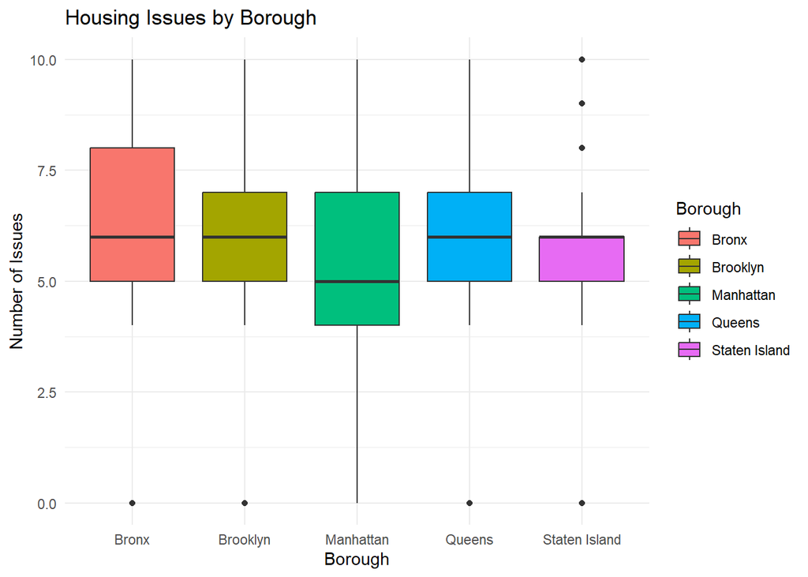

```r
# Visualize housing issues across boroughs
ggplot(combined_data, aes(x = boro, y = housing_issues, fill = boro)) +
  geom_boxplot() +
  labs(title = "Housing Issues by Borough", x = "Borough", y = "Number of Issues", fill = 'Borough') +
  theme_minimal()
```

Crowding and household size

```r
# Summary of crowding by borough
crowding_summary <- combined_data |>
  filter(crowding != -2) |>
  group_by(boro) |>
  summarize(
    avg_crowding = mean(crowding, na.rm = TRUE),
    overcrowded_percent = mean(crowding < 3, na.rm = TRUE) * 100,
    avg_household_size = mean(hhsize, na.rm = TRUE)
  )

print(crowding_summary)
```

```
## # A tibble: 5 × 4
##   boro          avg_crowding overcrowded_percent avg_household_size
##   <fct>                <dbl>               <dbl>              <dbl>
## 1 Bronx                 2.85               11.0                2.94
## 2 Brooklyn              2.87               10.0                3.21
## 3 Manhattan             2.92                7.03               2.64
## 4 Queens                2.87               10.4                3.37
## 5 Staten Island         2.92                7.80               3.61
```

Food insecurity

```r
# Summary of food insecurity and utility interruptions by borough
food_insecurity_summary <- combined_data |>
  filter(foodinsecure != "Not reported") |>
  group_by(boro) |>
  summarize(
    food_insecure_percent = mean(foodinsecure == "Insecure" | foodinsecure == "Very insecure", na.rm = TRUE) * 100,
  )

print(food_insecurity_summary)
```

```
## # A tibble: 5 × 2
##   boro          food_insecure_percent
##   <fct>                         <dbl>
## 1 Bronx                         10.1
## 2 Brooklyn                       7.16
## 3 Manhattan                      8
## 4 Queens                        10.1
## 5 Staten Island                  4.24
```

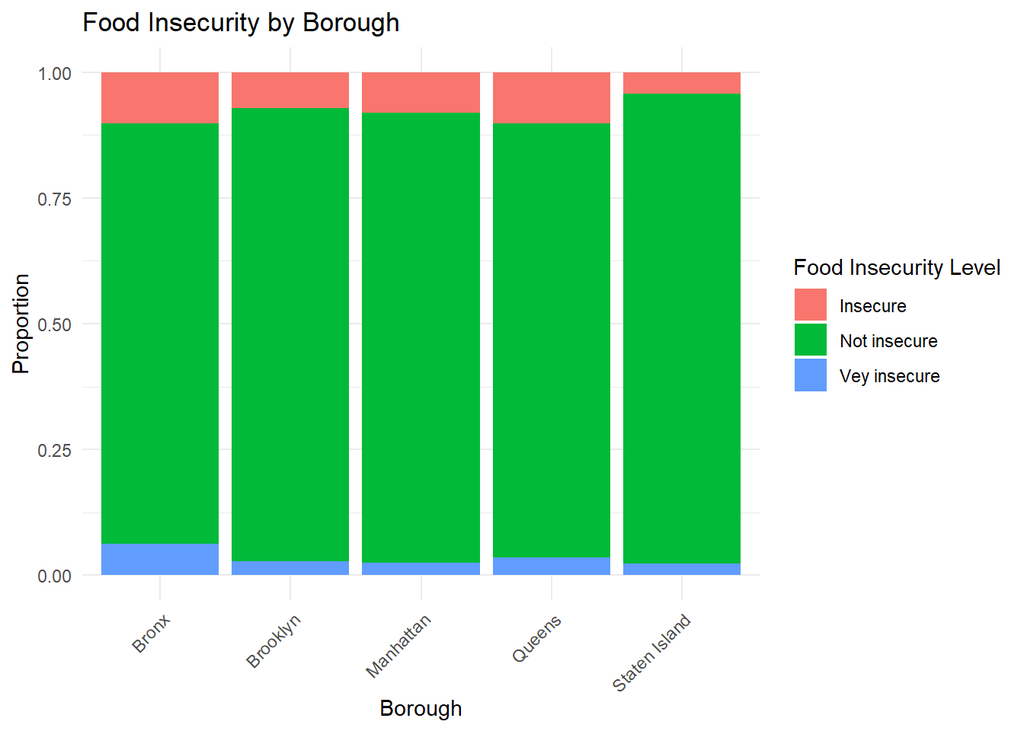

```r
# Visualize food insecurity by borough
ggplot(
  combined_data |>
    filter(foodinsecure != "Not reported"),
  aes(x = boro, fill = foodinsecure)
) +
  geom_bar(position = "fill") +
  labs(
    title = "Food Insecurity by Borough",
    x = "Borough",
    y = "Proportion",
    fill = "Food Insecurity Level"
  ) +
  theme_minimal() +
  theme(axis.text.x = element_text(angle = 45, hjust = 1))
```

```r
# Statistics of occ
occ_summary <- combined_data |>
  filter(
    hhpoverty != -2,
    rentburden_cat != "Not applicable",
    crowding != -2,
    foodinsecure != "Not reported"
  ) |>
  group_by(occ) |>
  summarize(
    avg_rentpaid = mean(rent_amount, na.rm = TRUE),
    avg_housing_issues = mean(housing_issues, na.rm = TRUE),
    avg_crowding = mean(crowding, na.rm = TRUE),
    avg_hhsize = mean(hhsize, na.rm = TRUE)
  )

print(occ_summary)
```

```
## # A tibble: 1 × 5
##   occ      avg_rentpaid avg_housing_issues avg_crowding avg_hhsize
##   <fct>           <dbl>              <dbl>        <dbl>      <dbl>
## 1 Occupied        1624.               6.28         2.84       3.01
```

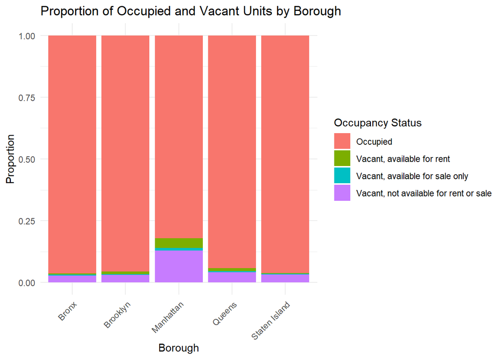

```r
# Bar plot for occupancy status by borough
ggplot(combined_data, aes(x = boro, fill = occ)) +
  geom_bar(position = "fill") +
  labs(
    title = "Proportion of Occupied and Vacant Units by Borough",
    x = "Borough",
    y = "Proportion",
    fill = "Occupancy Status"
  ) +
  theme_minimal() +
  theme(axis.text.x = element_text(angle = 45, hjust = 1))
```

## Analysis

```r
# Specify the columns to include in the PCA
housing_quality <- combined_data |>
  select(c("musty_freq", "elevator_status", "rodents_unit", "rodents_building", "toilet_status", "roaches_count", "wall_holes", "floor_holes", "peeling_paint", "large_peeling_paint", "boro"))|>
  drop_na()|>
  mutate(row_id = row_number()) |>
  mutate(across(c("musty_freq", "elevator_status", "rodents_unit", "rodents_building", "toilet_status", "roaches_count", "wall_holes", "floor_holes", "peeling_paint", "large_peeling_paint", "boro"),
                ~ as.numeric(as.factor(.))))



housing_quality_cols <-  c("musty_freq", "elevator_status", "rodents_unit", "rodents_building", "toilet_status", "roaches_count", "wall_holes", "floor_holes", "peeling_paint", "large_peeling_paint", "boro")
row_indices <- housing_quality$row_id
```

```r
# Create a recipe for PCA

pca_recipe <- recipe(~ ., data = housing_quality) |>
  update_role(all_of(housing_quality_cols), new_role = "predictor") |>
  update_role(c(row_id, boro), new_role = "id")|>
  step_normalize(all_predictors()) |>
  step_pca(all_predictors(), num_comp = 5)


# Prepare the recipe
pca_prep <- prep(pca_recipe)

# Apply the recipe to the data
pca_baked <- bake(pca_prep, new_data = NULL)

# Extract PCA loadings and variance
pca_loadings <- tidy(pca_prep, number = 2)

# Extract PCA scores
pca_scores <- pca_baked |>
  select(starts_with("PC"))

#combine scores with data
combined_data_pca <- combined_data[row_indices, ] |>
  bind_cols(pca_scores)

# View the results
#head(combined_data_pca)
```

The following plots were generated using code from https://juliasilge.com/blog/cocktail-recipes-umap/. The article was also a guide on how we interpreted the results of the analysis in the context of our dataset

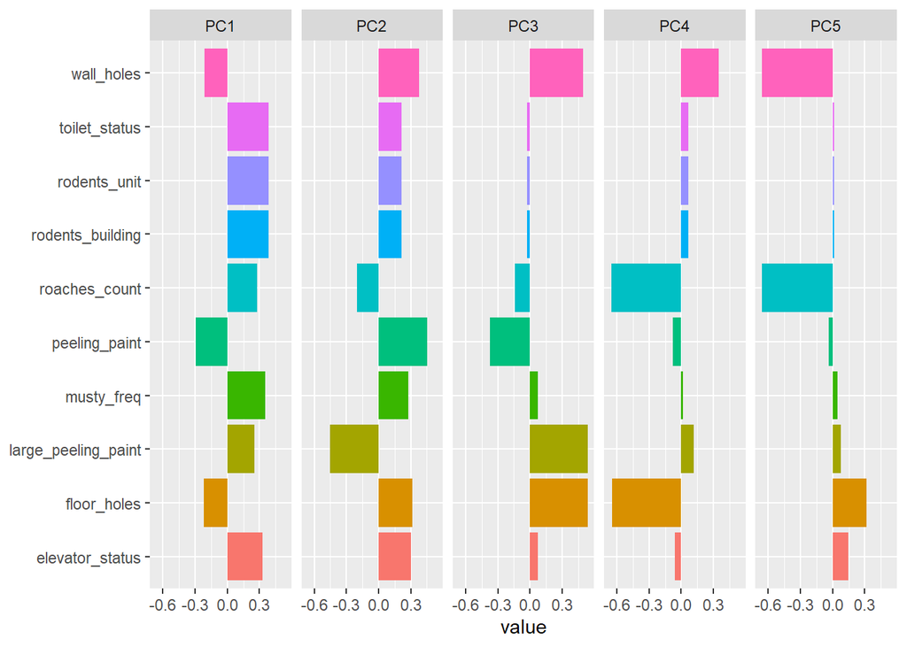

```r
tidied_pca <- tidy(pca_prep, 2)

tidied_pca |>
  filter(component %in% paste0("PC", 1:5)) |>
  mutate(component = fct_inorder(component)) |>
  ggplot(aes(value, terms, fill = terms)) +
  geom_col(show.legend = FALSE) +
  facet_wrap(~component, nrow = 1) +
  labs(y = NULL)
```

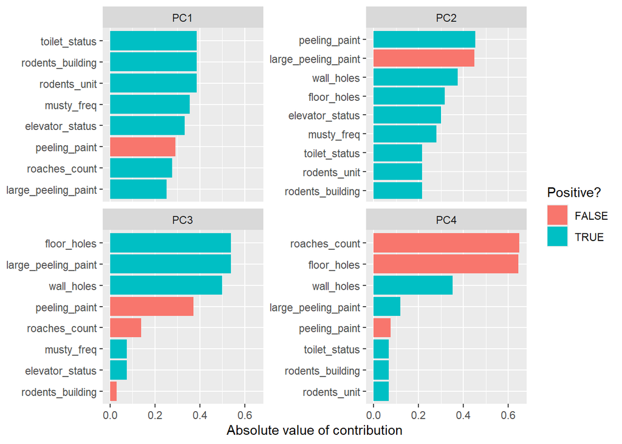

```r
tidied_pca |>
  filter(component %in% paste0("PC", 1:4))|>
  group_by(component) |>
  top_n(8, abs(value)) |>
  ungroup() |>
  mutate(terms = reorder_within(terms, abs(value), component)) |>
  ggplot(aes(abs(value), terms, fill = value > 0)) +
  geom_col() +
  facet_wrap(~component, scales = "free_y") +
  scale_y_reordered() +
  labs(
    x = "Absolute value of contribution",
    y = NULL, fill = "Positive?"
  )
```

```r
# Assuming PCA scores are in columns PC1, PC2, etc.
housing_pca <- combined_data_pca %>%
  select(PC1, raceeth_p)

# Calculate the mean PC1 score for each racial group
mean_pc1_by_race <- housing_pca %>%
  group_by(raceeth_p) %>%
  summarise(mean_PC1 = mean(PC1, na.rm = TRUE))

# View the results
print(mean_pc1_by_race)
```

```
## # A tibble: 7 × 2
##   raceeth_p                      mean_PC1
##   <chr>                             <dbl>
## 1 Asian alone, non-Hispanic       -0.247
## 2 Black alone, non-Hispanic        0.677
## 3 Hispanic                        -0.353
## 4 Indigenous or Pacific Islander   2.27
## 5 Multiracial                      1.19
## 6 White alone, non-Hispanic        0.173
## 7 <NA>                             0.0344
```

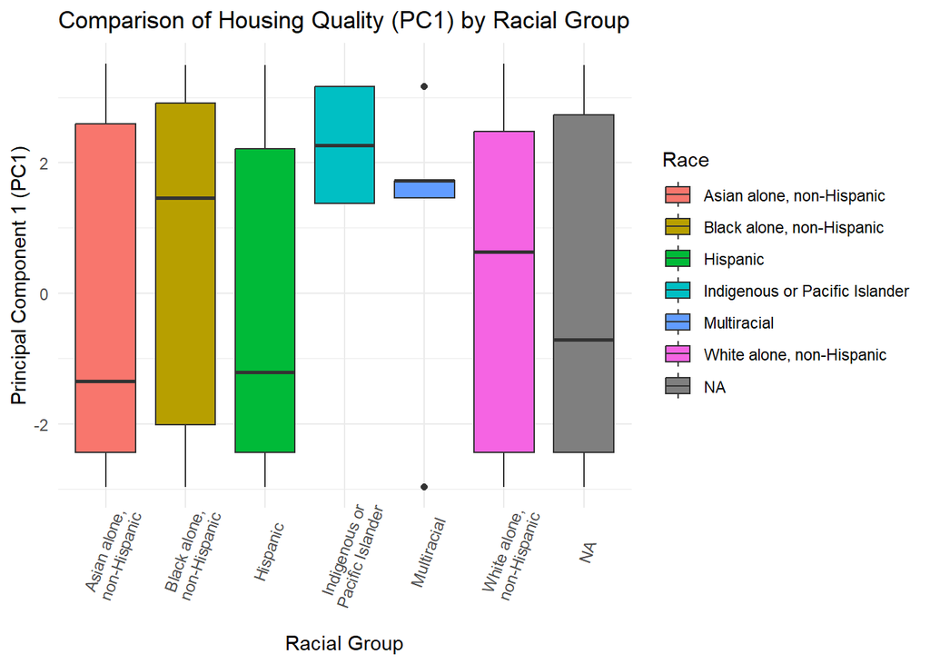

```r
# Create a boxplot to visualize the distribution of PC1 scores by racial group
ggplot(housing_pca, aes(x = raceeth_p, y = PC1, fill = raceeth_p)) +
  geom_boxplot() +
  labs(title = "Comparison of Housing Quality (PC1) by Racial Group", x = "Racial Group", y = "Principal Component 1 (PC1)", fill = 'Race') +
  theme_minimal() +
  theme(axis.text.x = element_text(vjust = 0.7, angle=70)) +
  scale_x_discrete(labels = ~ str_wrap(as.character(.x), 20))
```

## Results / Discussion

The final visualization highlights disparities in housing quality across different racial groups using PC1’s scores. Indigenous or Pacific Islander people have the highest mean PC1 scores, which indicates the most severe housing quality challenges. It is followed by family of “Other or two or more races” and Black family. In contrast, Hispanic and Asian households have lower PC1 scores, which suggest relatively better housing conditions. These disparities underscore systemic inequities with respect of housing quality, particularly affect marginalized groups.

## References

Chambon, D., & Gerszten, J. (2023). A statistical framework for analyzing housing quality: A case study of new york city. Computational Statistics, 38(4), 1669–1685. https://doi.org/10.1007/s00180-023-01394-w

CHCP New York City. Housing Conditions & Instability: A health crisis for NYC … CHCPNY New Lens. https://chpcny.org/wp-content/uploads/2016/09/General-Rx-for-Housing-Brief.pdf

EJNYC. (2024). Access to safe and healthy housing. NYC Mayor’s Office of Climate and Environmental Justice. https://climate.cityofnewyork.us/ejnyc-report/the-state-of-environmental-justice-in-nyc/access-to-safe-and-healthy-housing/#:~:text=According%20to%20Where%20We%20Live%20NYC%2C%20public%20housing%20residents%20reported,maintenance%20problems%20in%20their%20homes

Office of Budget Policy and Analysis. (2024, February). New Yorkers in need: The housing insecurity crisis. Office of the New York State Comptroller. https://www.osc.ny.gov/reports/new-yorkers-need-housing-insecurity-crisis

Raudales, A. A. (2024, July 26). Report: Living conditions in private, low-income housing are “horrendous.” City & State NY. https://www.cityandstateny.com/policy/2024/07/report-living-conditions-private-low-income-housing-are-horrendous/398348/

Silge, J. (2020, May 27). PCA and UMAP with tidymodels and #TidyTuesday cocktail recipes. Julia Silge. https://juliasilge.com/blog/cocktail-recipes-umap/

Zaveri, M. (2024, February 8). New York City’s housing crunch is the worst it has been in over 50 years. The New York Times. https://www.nytimes.com/2024/02/08/nyregion/apartment-vacancy-rate-housing-crisis.html